# CSE-221710307029-Gopi Bollineni

### Assignment-13[10-06-2020]

```python
import pandas as pd #Data Analysis & Data Manipulation using DataFrames
import numpy as np #For creating Multi-Dimensional Arrays and to perform array Manipulations
import matplotlib as plot #For Data visualization and statistical plotting of DATA
import seaborn as sea
%matplotlib inline
```

`Versions Of Each Packages`

```python
print("MATPLOTLIB: ",plot.__version__)
print("NUMPY: ",np.version.version)
print("PANDAS: ",pd.__version__)
print("SEABORN",sea.__version__)
```

```
MATPLOTLIB:  3.1.3
NUMPY:  1.18.1
PANDAS:  1.0.1
SEABORN 0.10.0
```

`Read Data using PANDAS and store in df`

```python
data=pd.read_csv(r'https://raw.githubusercontent.com/sumathi16/Datasets/master/upvotes.csv')
df=pd.DataFrame(data)
df.head(10)
```

|  | ID | Tag | Reputation | Answers | Username | Views | Upvotes |
| --- | --- | --- | --- | --- | --- | --- | --- |
| 0 | 52664 | a | 3942.0 | 2.0 | 155623 | 7855.0 | 42.0 |
| 1 | 327662 | a | 26046.0 | 12.0 | 21781 | 55801.0 | 1175.0 |
| 2 | 468453 | c | 1358.0 | 4.0 | 56177 | 8067.0 | 60.0 |
| 3 | 96996 | a | 264.0 | 3.0 | 168793 | 27064.0 | 9.0 |
| 4 | 131465 | c | 4271.0 | 4.0 | 112223 | 13986.0 | 83.0 |
| 5 | 345568 | r | 440.0 | 1.0 | 23866 | 5577.0 | 4.0 |
| 6 | 376865 | c | 147.0 | 1.0 | 10759 | 17184.0 | 17.0 |
| 7 | 467378 | j | 2269.0 | 2.0 | 54623 | 312.0 | 3.0 |
| 8 | 393640 | j | 111.0 | 2.0 | 172926 | 53738.0 | 79.0 |
| 9 | 130054 | c | 2749.0 | 1.0 | 10189 | 227.0 | 0.0 |

#### Understanding the data:

- How many rows are there in the data?
- How many columns are there?
- How many categorical columns are there?
- Print the categorical column names
- Print the numerical column names

```python
df.describe()
```

|  | ID | Reputation | Answers | Username | Views | Upvotes |
| --- | --- | --- | --- | --- | --- | --- |
| count | 330045.000000 | 3.300450e+05 | 330045.000000 | 330045.000000 | 3.300450e+05 | 330045.000000 |
| mean | 235748.682789 | 7.773147e+03 | 3.917672 | 81442.888803 | 2.964507e+04 | 337.505358 |
| std | 136039.418471 | 2.706141e+04 | 3.579515 | 49215.100730 | 8.095646e+04 | 3592.441135 |
| min | 1.000000 | 0.000000e+00 | 0.000000 | 0.000000 | 9.000000e+00 | 0.000000 |
| 25% | 117909.000000 | 2.820000e+02 | 2.000000 | 39808.000000 | 2.594000e+03 | 8.000000 |
| 50% | 235699.000000 | 1.236000e+03 | 3.000000 | 79010.000000 | 8.954000e+03 | 28.000000 |
| 75% | 353620.000000 | 5.118000e+03 | 5.000000 | 122559.000000 | 2.687000e+04 | 107.000000 |
| max | 471493.000000 | 1.042428e+06 | 76.000000 | 175738.000000 | 5.231058e+06 | 615278.000000 |

```python
print("No of ROWS: ",df.shape[0])
print("No of COLUMNS: ",df.shape[1])
print("No of Categorical Columns: ",len(df.columns[df.dtypes=='object']))
print("Categorical Columns names:  ")
for i in (df.columns[df.dtypes=='object']):
    print(i,end=",")
print("\nNumerical Column Names:  ")
for i in (df.columns[df.dtypes!='object']):
    print(i,end=",")
```

```
No of ROWS:  330045
No of COLUMNS:  7
No of Categorical Columns:  1
Categorical Columns names:
Tag,
Numerical Column Names:
ID,Reputation,Answers,Username,Views,Upvotes,
```

### Observe statistical description of the numerical columns:

#### draw a relplot by palcing views on y and upvotes on x:

1. draw the plot using data argument
2. draw the plot without using data argument

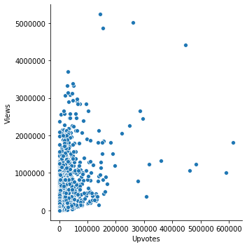

```python
#plotting using data argument
sea.relplot('Upvotes','Views',data=df)
```

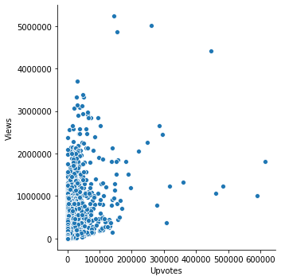

```python
#plotting without using data
sea.relplot('Upvotes','Views',None,None,None,df)
```

#### Add another argument for hue the above plot.

- check it with one numerical column as hue
- check it with one categorical column as hue

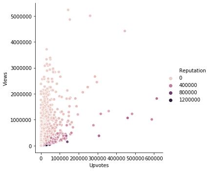

```python
#numerical Column as hue
sea.relplot('Upvotes','Views',data=df,hue='Reputation')
```

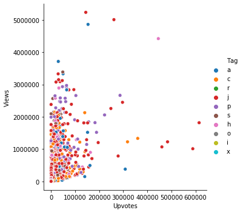

```python
#Categorical Column as hue
sea.relplot('Upvotes','Views',data=df,hue='Tag')
```

#### Write down your observations from above two graphs:

`observations from numerical hue value and Categorical hue Value :`

##### 1. color:

1. For numerical hue:
   - the color is a gradient it gradually increases contrast with increse in the value of the hue Variable.
2. For Categorical hue:
   - the color for each Value(category) is represented differently.

##### 2. Distribution:

1. For Numerical hue:
   - the distribution of the Scatter for the given Hue value is according to corresponding X and Y values of the axes.
2. For Categorical hue:
   - the distribution is irrespective of the X and Y values, the data is just grouped into the respective 'Tag' values.

### Modify the above plot using any of the parameters size,style,col:

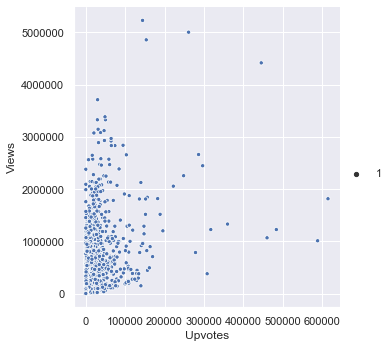

```python
sea.set(style='darkgrid')
sea.relplot('Upvotes','Views',data=df,size=1)
```

### Draw the cat plot by taking tag on xaxis and upvotes on yaxis:

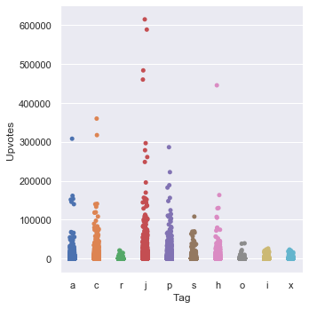

```python
sea.catplot('Tag','Upvotes',data=df)
```

### Draw the suitable plot to display How many questions are there for each Tag:

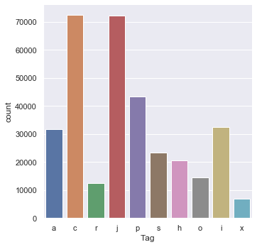

```python
sea.catplot('Tag',data=df,kind='count')
```

#### Draw the suitable plot which will provide estimated line fit for the Answers and Upvotes:

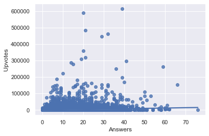

```python
sea.regplot('Answers','Upvotes',data=df)
```

#### Draw the boxplot for all the numerical columns:

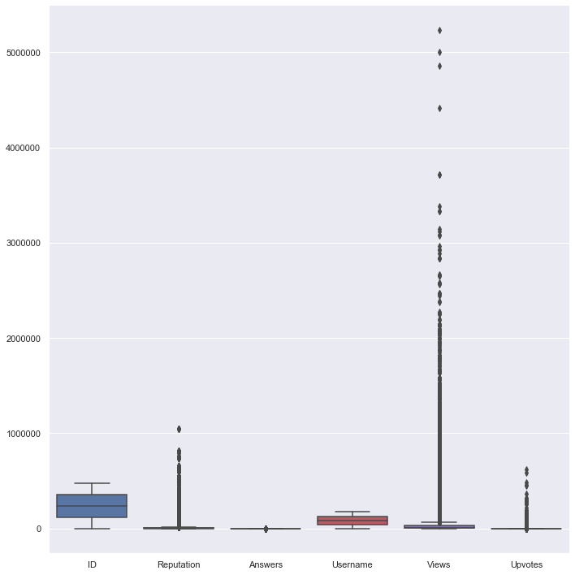

```python
sea.catplot(kind='box',data=df,size=10)
```

#### PairPlot:

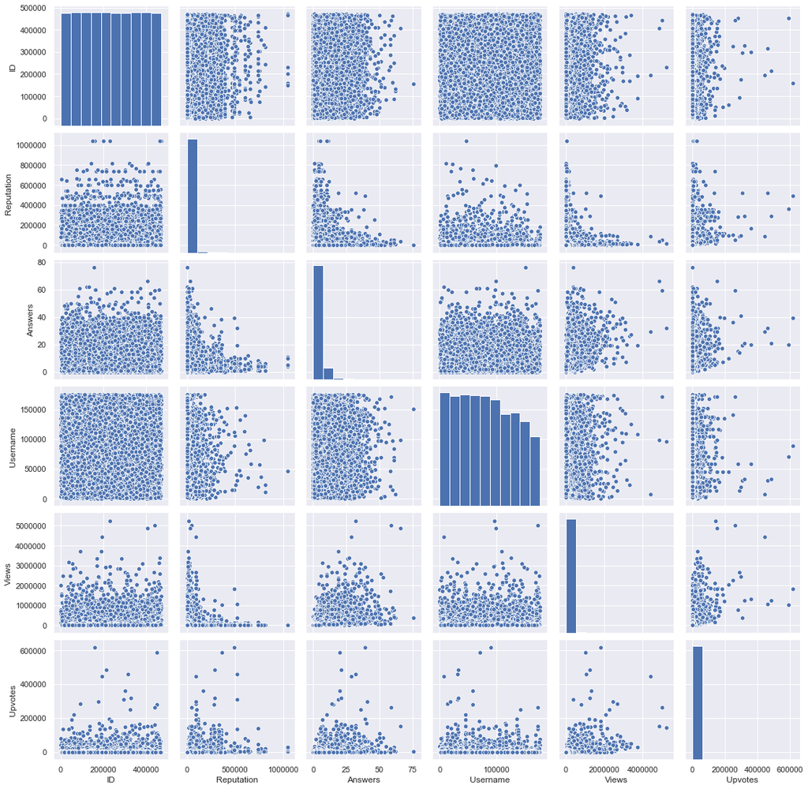

```python
sea.pairplot(df)
```

#### Correlation:

```python
df.corr()
```

|  | ID | Reputation | Answers | Username | Views | Upvotes |
| --- | --- | --- | --- | --- | --- | --- |
| ID | 1.000000 | 0.008546 | 0.017448 | 0.000628 | 0.017400 | 0.006328 |
| Reputation | 0.008546 | 1.000000 | 0.066504 | -0.041019 | 0.036455 | 0.266710 |
| Answers | 0.017448 | 0.066504 | 1.000000 | -0.012197 | 0.498642 | 0.202033 |
| Username | 0.000628 | -0.041019 | -0.012197 | 1.000000 | 0.002306 | -0.011970 |
| Views | 0.017400 | 0.036455 | 0.498642 | 0.002306 | 1.000000 | 0.437336 |
| Upvotes | 0.006328 | 0.266710 | 0.202033 | -0.011970 | 0.437336 | 1.000000 |

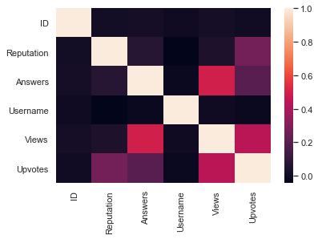

```python
sea.heatmap(df.corr())
```

#### Get the data with tag 'a' in a new dataframe with name df_taga:

```python
df_taga=df.groupby('Tag').get_group('a')
df_taga
```

|  | ID | Tag | Reputation | Answers | Username | Views | Upvotes |
| --- | --- | --- | --- | --- | --- | --- | --- |
| 0 | 52664 | a | 3942.0 | 2.0 | 155623 | 7855.0 | 42.0 |
| 1 | 327662 | a | 26046.0 | 12.0 | 21781 | 55801.0 | 1175.0 |
| 3 | 96996 | a | 264.0 | 3.0 | 168793 | 27064.0 | 9.0 |
| 30 | 106895 | a | 347.0 | 3.0 | 154557 | 22195.0 | 8.0 |
| 33 | 292364 | a | 9051.0 | 2.0 | 58930 | 46305.0 | 363.0 |
| ... | ... | ... | ... | ... | ... | ... | ... |
| 330018 | 343134 | a | 4503.0 | 6.0 | 169019 | 26688.0 | 140.0 |
| 330023 | 410941 | a | 28.0 | 5.0 | 99082 | 6004.0 | 10.0 |
| 330030 | 202255 | a | 476.0 | 3.0 | 106383 | 11537.0 | 13.0 |
| 330031 | 106211 | a | 1836.0 | 1.0 | 8874 | 4010.0 | 12.0 |
| 330034 | 468835 | a | 3165.0 | 15.0 | 98736 | 63005.0 | 422.0 |

31695 rows × 7 columns

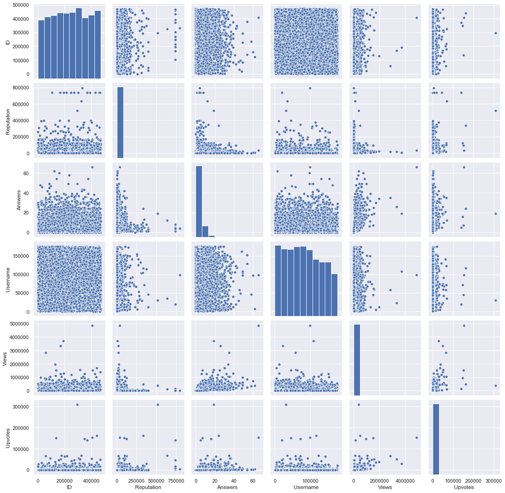

```python
sea.pairplot(df_taga)
```

[output not shown]

[output cut: 35 more lines]

[output not shown]

[figure not shown]

```python
sea.catplot('Views','Upvotes',data=df_taga)
```

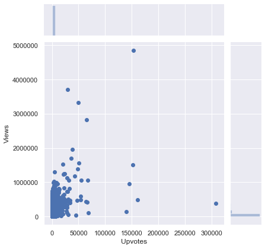

```python
sea.jointplot('Upvotes','Views',data=df_taga)
```

#### Create a new column with name 'Ans' using Answers column in the df:

- make the values which are 0 as Unanswered
- make the values which are in 1-20 range as 'Twenty'
- make the values which are in 21-40 range as 'Forty'
- make the values which are in 41-60 range as 'Sixty'
- make the values which are in 61-80 range as 'Eighty' ##### Here You are creating a categorical column from numerical ccolumn

```python
df.loc[(df['Answers']==0),'Ans'] = 'Unanswered'
df.loc[(df['Answers'] >=1) & (df['Answers'] <= 20), 'Ans'] = 'Twenty'
df.loc[(df['Answers'] >=21) & (df['Answers'] <= 40), 'Ans'] = 'Forty'
df.loc[(df['Answers'] >=41) & (df['Answers'] <= 60), 'Ans'] = 'Sixty'
df.loc[(df['Answers'] >=61) & (df['Answers'] <= 80), 'Ans'] = 'Eighty'
```

```python
df
```

|  | ID | Tag | Reputation | Answers | Username | Views | Upvotes | Ans |
| --- | --- | --- | --- | --- | --- | --- | --- | --- |
| 0 | 52664 | a | 3942.0 | 2.0 | 155623 | 7855.0 | 42.0 | Twenty |
| 1 | 327662 | a | 26046.0 | 12.0 | 21781 | 55801.0 | 1175.0 | Twenty |
| 2 | 468453 | c | 1358.0 | 4.0 | 56177 | 8067.0 | 60.0 | Twenty |
| 3 | 96996 | a | 264.0 | 3.0 | 168793 | 27064.0 | 9.0 | Twenty |
| 4 | 131465 | c | 4271.0 | 4.0 | 112223 | 13986.0 | 83.0 | Twenty |
| ... | ... | ... | ... | ... | ... | ... | ... | ... |
| 330040 | 339800 | c | 36.0 | 2.0 | 84919 | 1063.0 | 0.0 | Twenty |
| 330041 | 253800 | c | 1649.0 | 2.0 | 76730 | 23319.0 | 73.0 | Twenty |
| 330042 | 210756 | c | 6178.0 | 2.0 | 91701 | 2453.0 | 15.0 | Twenty |
| 330043 | 56089 | j | 89.0 | 2.0 | 80245 | 2107.0 | 3.0 | Twenty |
| 330044 | 300553 | j | 2001.0 | 4.0 | 154692 | 2554.0 | 37.0 | Twenty |

330045 rows × 8 columns

#### Draw a boxplot by taking Ans column on Xaxis and Upvotes on Y axis

- try this with boxplot
- try this with catplot

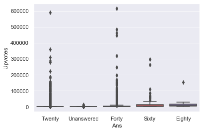

```python
sea.boxplot(x="Ans", y="Upvotes", data=df)
```

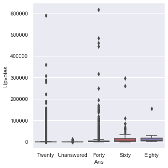

```python
sea.catplot("Ans","Upvotes",data=df,kind='box')
```